[figure not shown]

# Qubetics: The World's First Layer 1, Web3 Aggregated Ecosystem That Unites Leading Blockchains Including Bitcoin, Ethereum, Solana & More.

Qubetics Network is redefining blockchain technology. We aim to build a highly efficient, self-sustaining ecosystem designed to effortlessly manage a large number of transactions.

Access to 12.85% of the total $TICS supply is available now during our live crypto presale. This unique opportunity allows you to participate early and grow with our expanding community.

Join now

[interactive chart not shown]

# The Qubetics All-In-One Crypto Powerhouse

Meet the Qubetics multi-chain crypto Wallet—a non-custodial, open-source powerhouse. Enjoy feeless $TICS transfers in-app, debit & virtual cards, seamless Apple Pay and Google Pay integration, a decentralized VPN (dVPN) service, and access to a tokenized asset marketplace, all conveniently housed in one application.

[Learn More](https://www.qubetics.com/wallets)

# Transforming Asset Acquisition with the Qubetics Platform

Our Web3-powered tokenized asset marketplace on Qubetics will simplify the acquisition of digital assets by removing traditional barriers, fostering a new approach to asset exchange. This decentralized platform ensures equal access for all participants to emerging opportunities within the ecosystem.

Buy Now

[figure not shown]

Real Estate

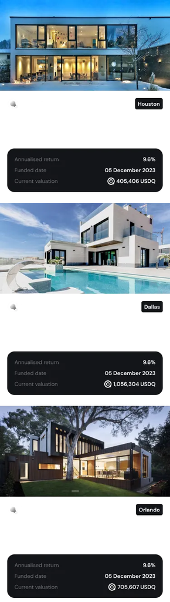

Try Me

Experience a preview of  
our upcoming app's features!

[interactive chart not shown]

# The Qubetics Network's initiative for banks and financial institutions is a significant step toward modernizing the global financial landscape.

The integration of QUSD tokens with the dollar-backed Tether/Circle (USDT/USDC) introduces stability to the crypto environment, closely mirroring real-world currency values. This strategic connection between Qubetics and QUSD aims to enhance the utility of the TICS token, drawing users to its dependable and promising features.

[Learn More](https://www.qubetics.com/banks-and-institutions)

# Decentralized VPN Redefining Internet Privacy and Freedom

The Qubetics ecosystem introduces a decentralized VPN (dVPN) service designed to enhance security, privacy, and access to an unrestricted internet. Unlike traditional centralized VPN providers that can log, censor, or restrict user data. Operating on a fully decentralized, peer-to-peer network, ensures that no single authority controls user traffic or data. This decentralized model leverages blockchain technology to offer unparalleled transparency, privacy, and resistance to censorship

[Learn More](https://www.qubetics.com/dvpn)

[interactive chart not shown]

# Explore the transformative power of QubeQode development methodologies.

At Qubetics, we simplify blockchain technology with our QubeQode tools. These tools not only ease ICO launches but also empower a range of blockchain applications—from smart contract creation to asset tokenization, offering limitless innovation possibilities.

[video not shown]

## Effortlessly Craft NFTs for Events and More with the Qubetics QubeQode Platform Tools

[video not shown]

[figure not shown]

# Unleash your creativity and streamline your event management with Qubetics’ innovative QubeQode platform features

Imagine effortlessly generating NFT QR codes for music events, enabling secure ticketing, exclusive access, and unique fan experiences, all with a few clicks. Using our planned intuitive platform, anyone can design and deploy these NFTs without prior coding knowledge, thanks to AI-guided prompts and drag-and-drop functionalities. Beyond music events, the possibilities are limitless; from personalized event memorabilia to loyalty rewards and beyond, Qubetics will empower you to transform any idea into a blockchain reality, making advanced technology accessible to all.

[Learn More](https://www.qubetics.com/qubeqode)

# Shaping a New Era of Financial Interaction with QUSD

The integration of $TICS tokens with the soon-to-be-deployed USDC/USDT-backed QUSD, promotes market stability and accurate transaction reflections, enhancing user confidence. This strategic pairing is designed to increase demand for $TICS, fostering enhanced utility and user engagement due to its security and potential.

[Learn More](https://www.qubetics.com/qubetics-usd)

[interactive chart not shown]

# Tokenomics

The total supply of tokens will be determined by the amount sold during the presale, which will consistently represent 12.85% of the total supply. This approach ensures flexibility and scalability in managing the supply based on participant interest and investment.

[figure not shown]

[interactive chart not shown]

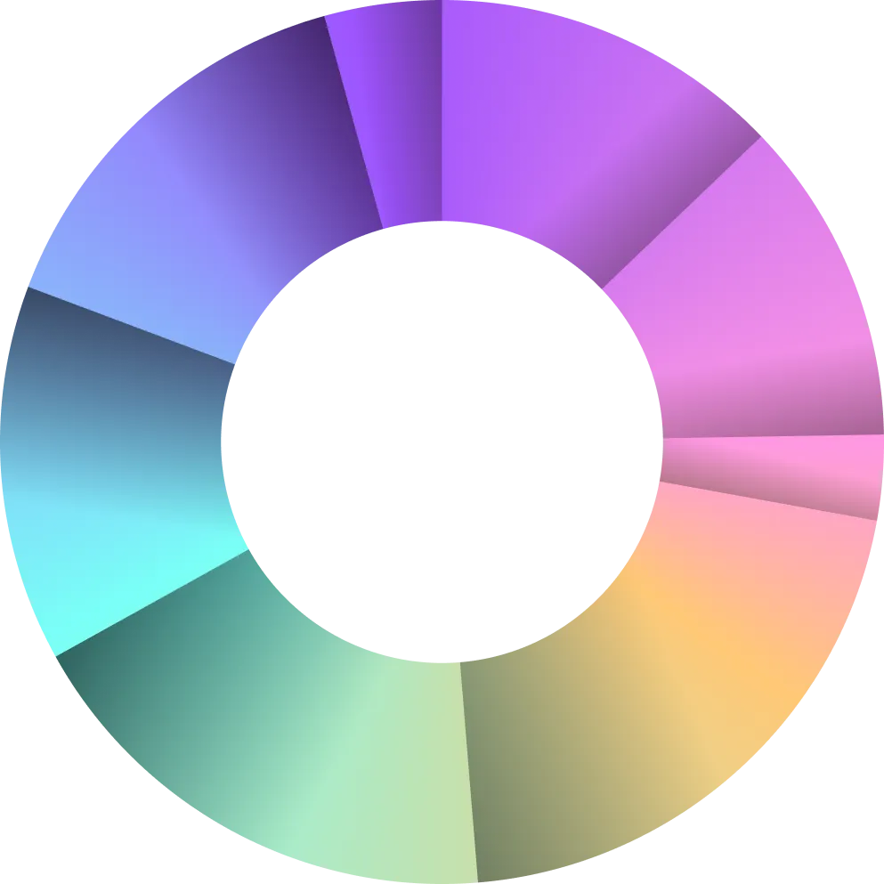

[figure not shown]

Community Incentives 4.29%

Reserves 15.00%

Network Operations 13.78%

Foundation 18.23%

Public Sale 12.85%

Team 11.88%

Advisors 3.12%

Ecosystem 20.85%

The distribution of these tokens is meticulously planned to ensure the long-term sustainability and growth of the network

[Learn More](https://www.qubetics.com/tokenomics)

[figure not shown]

# Roadmap

Q1 2024: January - March

## Conceptualization and Strategic Planning

- Define core objectives and vision for Qubetics Network.
- Outline the initial project scope and key milestones.
- Conduct market research and feasibility studies.

Q2 2024: April - June

## Team Establishment and Foundation Building

- Recruit and onboard key team members.
- Launch the whitelist website for early adopters.
- Begin drafting the Qubetics whitepaper.
- Attend the Blockchain Life Expo in Dubai.
- Conduct an interview with Web3TV to increase visibility.
- Engage with key figures in the blockchain industry for strategic insights.
- Partner with developers to begin the technical groundwork.
- Finalize the draft of the whitepaper.
- Design the ICO website.
- Develop and test a comprehensive marketing strategy.
- Identify and define the scope of the Qubetics blockchain.
- Initiate marketing efforts to raise awareness about the whitelist.
- Publish articles and press releases to build initial momentum.

Q3 2024: July - September

## Strategic Partnerships and Preparations

- Continue to drive whitelist marketing efforts.
- Refine and enhance the whitepaper based on feedback.
- Establish a partnership with Blockaid for security assurance.
- Set up the Qubetics GitHub environment for collaborative development.
- Finalize the scope of the blockchain project.
- Complete the design and functionality of the ICO website.
- Finalize the design and layout of the whitepaper.
- Partner with PhishFort for additional security measures.
- Pre-sale initiation.
- Participate in Token 2049 Singapore for global exposure.
- Form strategic partnerships with financial service providers.

Q4 2024: October - December

## Core Development and Community Engagement

- Begin the development of Qubetics' core blockchain technology.
- Development of decentralized VPN.
- Start development of the testnet environment.
- Expand marketing efforts to reach a broader audience.
- Initiate the development of the Qubetics wallet.
- Focus on community expansion through targeted campaigns.
- Host live AMAs (Ask Me Anything) sessions with key team members.
- Strengthen existing partnerships and explore new collaborations.

Q1 2025: January - March

## Mainnet Preparation and Beta Testing

- Prepare for the launch of the Qubetics mainnet.
- Development of Chain Abstraction - EVM Chains.
- Develop and beta test the Qubetics marketplace.
- Continue hosting live AMAs to engage with the community.
- Expand marketing efforts in anticipation of the mainnet launch.
- Deploy the testnet and invite the community for testing and feedback.
- Conduct beta testing of the Qubetics wallet.
- Begin the development phase for the mainnet.
- Host a hackathon to encourage community-driven development.
- Launch a bug bounty program to ensure the network's security and robustness.

Q2 2025: April - June

## Mainnet Launch and Ecosystem Expansion

- Officially launch the Qubetics mainnet v1.0.
- Launch of Chain Abstraction - EVM Chains.
- Conduct thorough audits of the blockchain for security and performance.
- Expand the functionality of the Qubetics wallet with new features.

Q3 2025: July - September

## Mainnet Launch and Ecosystem Expansion

- Officially launch the Qubetics mainnet v1.1.
- Launch of Chain Abstraction - Wasm Chains(Polkadot & Cosmos)
- Launch of Qubetics foundation.
- Ecosystem grants and incentives.

Q4 2025: October - December

## Mainnet Launch and Ecosystem Expansion

- Officially launch the Qubetics mainnet v1.2.
- Launch of Chain Abstraction - Bitcoin and Remaining Chains.

# Partners

[figure not shown]

[figure not shown]

[figure not shown]

[figure not shown]

# Q & A

Qubetics is a layer 1 WEB3 aggregated blockchain that will unify all blockchain networks including BTC, focusing on scalability, security and interoperability. Qubetics aims to be the leading blockchain network for financial service, payment solutions and digitization of real-world asset.

Qubetics stands out by integrating EVM, Wasm and Bitcoin chain abstraction enabling interoperability with all blockchain networks, a tokenized asset market place, a Decentralized VPN service, a non-custodial open-source wallet with debit and virtual card functionality and QubeQode IDE, enabling financial solutions catering to both individuals and institutions.

An aggregated blockchain brings together multiple blockchain networks, enabling them to interact smoothly and operate as a unified system. This integration enhances cross-chain interoperability, scalability, and security, facilitating the seamless exchange and utilization of assets, data, and smart contracts across various platforms.

A decentralized VPN (dVPN) offers enhanced privacy, security, and censorship resistance by using a distributed network of nodes instead of centralized servers. This decentralized structure prevents data logging, making it difficult for third parties to monitor or block user activity, fostering resilience against hacking or shutdown attempts.

QubeQode is an integrated development environment designed for the Qubetics Network that simplifies blockchain development with a drag-and-drop interface, making it accessible even to those with limited coding experience. Enhanced with AI components, it automates the creation and deployment of smart contracts and decentralized applications (dApps).

It's a platform within the Qubetics Wallet App, where users can buy, sell, or hold various real world assets (RWA)